# Tidying and Analyzing Wide Data

## 3.2 Tidy Data

We convert the data to long format for flexible analysis.

```r
country_long <- country_demo %>%
  pivot_longer(
    cols = -Country,
    names_to = c("Measure", "Year"),
    names_sep = "_",
    values_to = "Value"
  ) %>%
  mutate(Year = as.integer(Year))
```

**Description:**  
Long format allows us to easily summarize, plot, and model each measure over time and across countries.

## 3.3 Summary and Confidence Intervals

We compute mean, SD, and 95% CI for each measure and year globally.

```r
global_summary <- country_long %>%
  group_by(Measure, Year) %>%
  summarize(
    mean_value = mean(Value, na.rm=TRUE),
    sd_value = sd(Value, na.rm=TRUE),
    n = n(),
    se = sd_value/sqrt(n),
    ci_lower = mean_value - qt(0.975, n-1)*se,
    ci_upper = mean_value + qt(0.975, n-1)*se,
    .groups="drop"
  )
global_summary
```

```
## # A tibble: 6 × 8
##   Measure  Year mean_value sd_value     n      se ci_lower ci_upper
##   <chr>   <int>      <dbl>    <dbl> <int>   <dbl>    <dbl>    <dbl>
## 1 GDP      2010     1210.   2320.      52 322.       564.    1856.
## 2 GDP      2020     1701.   3462.      52 480.       737.    2665.
## 3 LifeExp  2010       76.3     6.44    52   0.893     74.5     78.0
## 4 LifeExp  2020       78.3     5.78    52   0.801     76.7     79.9
## 5 Pop      2010      106.    244.      52  33.9       37.9    174.
## 6 Pop      2020      118.    271.      52  37.6       42.1    193.
```

**Description:**  
This table allows us to compare global trends and the precision of our global estimates for population, GDP, and life expectancy.

## 3.4 Visualization (with Error Bars for Life Expectancy Only)

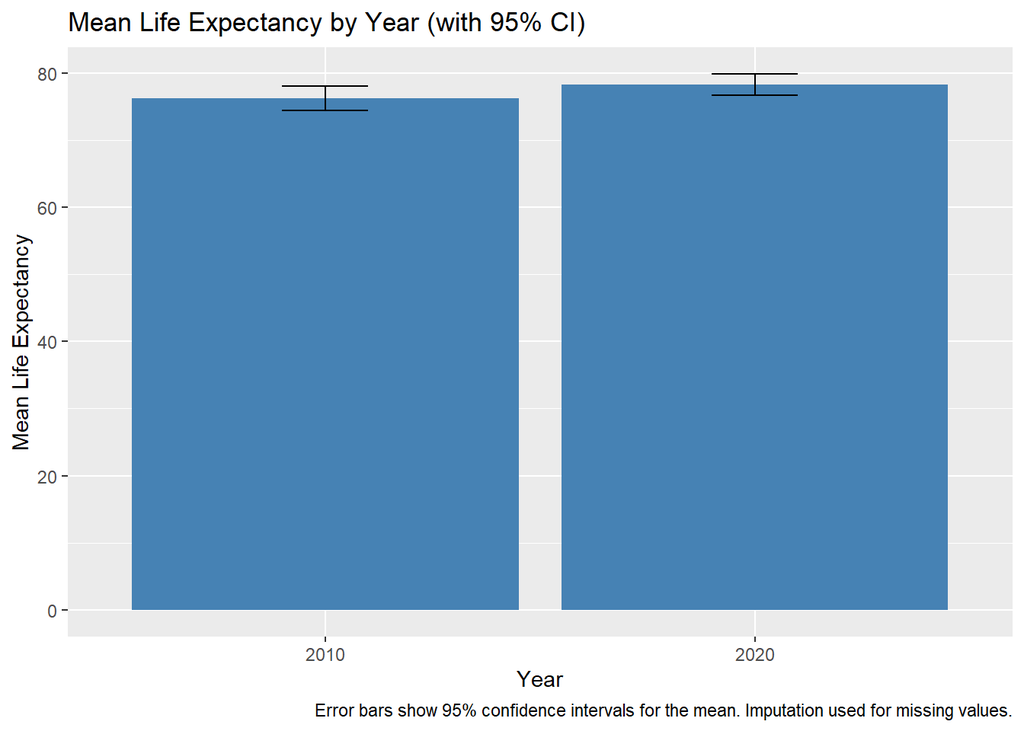

```r
ggplot(global_summary %>% filter(Measure=="LifeExp"),
       aes(x=factor(Year), y=mean_value, group=1)) +
  geom_col(fill="steelblue") +
  geom_errorbar(aes(ymin=ci_lower, ymax=ci_upper), width=0.2) +
  labs(title="Mean Life Expectancy by Year (with 95% CI)",
       x="Year", y="Mean Life Expectancy",
       caption="Error bars show 95% confidence intervals for the mean. Imputation used for missing values.")
```

**Description:**  
This bar plot summarizes changes in global life expectancy, with error bars reflecting the uncertainty in the estimate. Such error bars are essential for honest reporting and allow us to judge if observed differences are likely to be meaningful.

## 3.5 Inferential Test: Paired t-test (GDP 2010 vs 2020)

To test for significant GDP growth, we use a paired t-test for each country’s GDP across the two years.

```r
gdp10 <- country_demo$GDP_2010
gdp20 <- country_demo$GDP_2020
t_test_gdp <- t.test(gdp10, gdp20, paired=TRUE)
t_test_gdp
```

```
##
##  Paired t-test
##
## data:  gdp10 and gdp20
## t = -2.5593, df = 51, p-value = 0.0135
## alternative hypothesis: true mean difference is not equal to 0
## 95 percent confidence interval:
##  -875.7092 -105.7848
## sample estimates:
## mean difference
##        -490.747
```

**Description & Interpretation:**  
The paired t-test formally assesses whether GDP has increased across the globe from 2010 to 2020. A p-value below 0.05 means the increase is statistically significant.

# Conclusion

This project demonstrates, with thorough narrative and code: - **How to identify and handle missing or malformed data**, using both detection and imputation techniques for transparency and rigor. - **How to tidy wide data** into long format using `pivot_longer`, facilitating modern data analysis. - **How to summarize and visualize results** with error bars and detailed captions that communicate reliability and uncertainty. - **How to apply and interpret inferential statistical tests** on real-world data, offering evidence-based conclusions. - **How to document the analysis process** with clear, specific, and thorough explanations at every step, ensuring reproducibility and best practices in data science.